# 한국행정지도(2014) 패키지 kormaps2014 데이터 수정

Keon-Woong Moon

2017-10-23

```
웹R의 운영자 문건웅입니다. 2014년 한국행정지도를 이용하여 단계구분도를 쉽게 만들 수 있게 해 주는 kormaps2014 패키지를 소개합니다. Shape데이타를 데이타프레임으로 미리 변환하였으므로 ggplot2등을 이용하여 쉽게 단계구분도를 그릴 수 있습니다.
제가 만든 다른 피키지 moonBook2에 있는  ggChoropleth()함수를 이용하면 보다 쉽게 단계구분도를 그릴 수 있습니다. static image뿐만 아니라 tooltip 사용  및 축소 확대 가능한 interactive plot도 쉽게 그릴 수 있습니다.
```

# 패키지 설치

kormaps패키지는 github에 있습니다. CRAN에 올릴 수는 있으나 한글을 모두 unicode로 변환해야 해서 사용하기 번거로와 github에 올렸습니다. github에 있는 패키지를 설치하려면 devtools 패키지에 있는 install_github()함수를 사용합니다.

```r
# install.packages("devtools")
devtools::install_github("cardiomoon/kormaps2014")
```

moonBook2패키지를 설치하시려면 다음과 같이 합니다. 처음 설치하는 경우 많은 패키지를 설치하므로 시간이 조금 걸립니다.

```r
devtools::install_github("cardiomoon/moonBook2")
```

# 패키지의 내용

패키지를 사용하려면 다음과 같이 패키지를 불러옵니다.

```r
library(kormaps2014)
library(moonBook2)
library(tidyverse)
library(GISTools)
```

kormaps 패키지에는 areacode, kormap1, kormap2, kormap3, korpop1, korpop2, korpop3, tbc데이타가 포함되어 있습니다.

### 데이타 areacode

`areacode` 의 `code`는 `factor` 이어야 합니다. 그리고 `name`과 `name1`도 마찬가지입니다. 이를 한번에 수행하기 위해서 사용자 함수를 정의합니다. `levels =`를 설정하지 않으면 한글 가나다 순으로 `1, 2, 3, ...`의 `level`이 부여됩니다. `ggplot()` 등으로 그래프를 그리면 `강원도, 경기도, ...`순으로 나오게 되는 이유입니다.

```r
rm(list = ls())
areacode
```

```
   code           name name1
1    11     서울특별시  서울
2    21     부산광역시  부산
3    22     대구광역시  대구
4    23     인천광역시  인천
5    24     광주광역시  광주
6    25     대전광역시  대전
7    26     울산광역시  울산
8    29 세종특별자치시  세종
9    31         경기도  경기
10   32         강원도  강원
11   33       충청북도  충북
12   34       충청남도  충남
13   35       전라북도  전북
14   36       전라남도  전남
15   37       경상북도  경북
16   38       경상남도  경남
17   39 제주특별자치도  제주
```

```r
areacode2 <- lapply(areacode, function(x) factor(x, levels = x))
areacode2 <- areacode2 %>%
        as_tibble()
str(areacode2)
```

```
Classes 'tbl_df', 'tbl' and 'data.frame':   17 obs. of  3 variables:
 $ code : Factor w/ 17 levels "11","21","22",..: 1 2 3 4 5 6 7 8 9 10 ...
 $ name : Factor w/ 17 levels "서울특별시","부산광역시",..: 1 2 3 4 5 6 7 8 9 10 ...
 $ name1: Factor w/ 17 levels "서울","부산",..: 1 2 3 4 5 6 7 8 9 10 ...
```

```r
areacode2
```

```
# A tibble: 17 x 3
     code           name  name1
   <fctr>         <fctr> <fctr>
 1     11     서울특별시   서울
 2     21     부산광역시   부산
 3     22     대구광역시   대구
 4     23     인천광역시   인천
 5     24     광주광역시   광주
 6     25     대전광역시   대전
 7     26     울산광역시   울산
 8     29 세종특별자치시   세종
 9     31         경기도   경기
10     32         강원도   강원
11     33       충청북도   충북
12     34       충청남도   충남
13     35       전라북도   전북
14     36       전라남도   전남
15     37       경상북도   경북
16     38       경상남도   경남
17     39 제주특별자치도   제주
```

### 한국행정지도 데이타

1. kormap1 : 2014년 한국행정지도(시도별)
2. kormap2 : 2014년 한국행정지도(시군구별)
3. kormap3 : 2014년 한국행정지도(읍면동별)

`str()`을 적용한 결과물을 보면 `SIDO_NM`, `name1`에 인코딩 문제로 인한 이상한 글자가 보인다. 또한 `SP_ID`의 순서가 “0”, “1”, “10”, “11” 로 되어 있어서 수정이 필요하다. 우선 시도 데이터를 살펴보자. `%>%` 는 작업의 흐름을 잘 보여주는 piping 이다.

### 시도 지도 데이터

#### `SIDO_NM`

시도의 이름에 해당 하는 이 변수는 `name`에서 반복되는 데 `name`에서는 가나다 순에 따라 `강원도, 경기도, ...` 순으로 `factor level`이 자동 설정되어 있다. 좌표 변환 과정에서 위도가 잘못 계산되었음이 명확하다. 이 부분은 원시 shape 파일이 있어야 손볼 수 있다.

```r
str(kormap1)
```

```
## 'data.frame':    8831 obs. of  15 variables:
##  $ id       : chr  "0" "0" "0" "0" ...
##  $ long     : num  138 138 138 138 138 ...
##  $ lat      : num  50.7 50.7 50.7 50.7 50.7 ...
##  $ order    : int  1 2 3 4 5 6 7 8 9 10 ...
##  $ hole     : logi  FALSE FALSE FALSE FALSE FALSE FALSE ...
##  $ piece    : Factor w/ 113 levels "1","2","3","4",..: 1 1 1 1 1 1 1 1 1 1 ...
##  $ group    : Factor w/ 205 levels "0.1","1.1","1.2",..: 1 1 1 1 1 1 1 1 1 1 ...
##  $ SP_ID    : Factor w/ 17 levels "0","1","10","11",..: 1 1 1 1 1 1 1 1 1 1 ...
##  $ SIDO_CD  : Factor w/ 17 levels "11","21","22",..: 1 1 1 1 1 1 1 1 1 1 ...
##  $ SIDO_NM  : Factor w/ 17 levels "\xb0\xad\xbf\xf8\xb5\xb5",..: 9 9 9 9 9 9 9 9 9 9 ...
##  $ BASE_YEAR: Factor w/ 1 level "2014": 1 1 1 1 1 1 1 1 1 1 ...
##  $ name     : Factor w/ 17 levels "강원도","경기도",..: 9 9 9 9 9 9 9 9 9 9 ...
##  $ name1    : Factor w/ 17 levels "\xb0\xad\xbf\xf8\xb5\xb5",..: 9 9 9 9 9 9 9 9 9 9 ...
##  $ region   : Factor w/ 17 levels "11","21","22",..: 1 1 1 1 1 1 1 1 1 1 ...
##  $ code     : Factor w/ 17 levels "11","21","22",..: 1 1 1 1 1 1 1 1 1 1 ...
```

```r
# kormap1$SIDO_NM <- kormap1$SIDO_NM %>%
#         as.character() %>% #> `factor`를 먼저 `character`롤 변환. `factor`는 사실상 1, 2, 3, ...
#         iconv(from = "CP949", to = "UTF-8") %>% #> `CP949`로 인코딩되어 있는 것을 `UTF-8`으로
#         factor(levels = areacode2$name) #> 앞에서 수정한 `areacode2` 활용. `areacode`는 어떻게?
```

```
#> 위의 piping 을 한줄로 처리하면
```

```r
kormap1$SIDO_NM <- factor(iconv(as.character(kormap1$SIDO_NM),
                                from = "CP949",
                                to = "UTF-8"),
                          levels = areacode2$name)
str(kormap1)
```

```
## 'data.frame':    8831 obs. of  15 variables:
##  $ id       : chr  "0" "0" "0" "0" ...
##  $ long     : num  138 138 138 138 138 ...
##  $ lat      : num  50.7 50.7 50.7 50.7 50.7 ...
##  $ order    : int  1 2 3 4 5 6 7 8 9 10 ...
##  $ hole     : logi  FALSE FALSE FALSE FALSE FALSE FALSE ...
##  $ piece    : Factor w/ 113 levels "1","2","3","4",..: 1 1 1 1 1 1 1 1 1 1 ...
##  $ group    : Factor w/ 205 levels "0.1","1.1","1.2",..: 1 1 1 1 1 1 1 1 1 1 ...
##  $ SP_ID    : Factor w/ 17 levels "0","1","10","11",..: 1 1 1 1 1 1 1 1 1 1 ...
##  $ SIDO_CD  : Factor w/ 17 levels "11","21","22",..: 1 1 1 1 1 1 1 1 1 1 ...
##  $ SIDO_NM  : Factor w/ 17 levels "서울특별시","부산광역시",..: 1 1 1 1 1 1 1 1 1 1 ...
##  $ BASE_YEAR: Factor w/ 1 level "2014": 1 1 1 1 1 1 1 1 1 1 ...
##  $ name     : Factor w/ 17 levels "강원도","경기도",..: 9 9 9 9 9 9 9 9 9 9 ...
##  $ name1    : Factor w/ 17 levels "\xb0\xad\xbf\xf8\xb5\xb5",..: 9 9 9 9 9 9 9 9 9 9 ...
##  $ region   : Factor w/ 17 levels "11","21","22",..: 1 1 1 1 1 1 1 1 1 1 ...
##  $ code     : Factor w/ 17 levels "11","21","22",..: 1 1 1 1 1 1 1 1 1 1 ...
```

#### `name1`

`서율, 부산, ...` 등 두 글자 약칭이 등장해야 하는데 뭔가 오류가 났었던 듯,

```r
str(kormap1)
```

```
## 'data.frame':    8831 obs. of  15 variables:
##  $ id       : chr  "0" "0" "0" "0" ...
##  $ long     : num  138 138 138 138 138 ...
##  $ lat      : num  50.7 50.7 50.7 50.7 50.7 ...
##  $ order    : int  1 2 3 4 5 6 7 8 9 10 ...
##  $ hole     : logi  FALSE FALSE FALSE FALSE FALSE FALSE ...
##  $ piece    : Factor w/ 113 levels "1","2","3","4",..: 1 1 1 1 1 1 1 1 1 1 ...
##  $ group    : Factor w/ 205 levels "0.1","1.1","1.2",..: 1 1 1 1 1 1 1 1 1 1 ...
##  $ SP_ID    : Factor w/ 17 levels "0","1","10","11",..: 1 1 1 1 1 1 1 1 1 1 ...
##  $ SIDO_CD  : Factor w/ 17 levels "11","21","22",..: 1 1 1 1 1 1 1 1 1 1 ...
##  $ SIDO_NM  : Factor w/ 17 levels "서울특별시","부산광역시",..: 1 1 1 1 1 1 1 1 1 1 ...
##  $ BASE_YEAR: Factor w/ 1 level "2014": 1 1 1 1 1 1 1 1 1 1 ...
##  $ name     : Factor w/ 17 levels "강원도","경기도",..: 9 9 9 9 9 9 9 9 9 9 ...
##  $ name1    : Factor w/ 17 levels "\xb0\xad\xbf\xf8\xb5\xb5",..: 9 9 9 9 9 9 9 9 9 9 ...
##  $ region   : Factor w/ 17 levels "11","21","22",..: 1 1 1 1 1 1 1 1 1 1 ...
##  $ code     : Factor w/ 17 levels "11","21","22",..: 1 1 1 1 1 1 1 1 1 1 ...
```

```r
# kormap1$name1 <- kormap1$name1 %>%
#         as.character() %>%
```

```
#> `factor`를 먼저 `character`롤 변환. `factor`는 사실상 1, 2, 3, ...
```

```r
#         iconv(from = "CP949", to = "UTF-8") %>%
```

```
#> `CP949`로 인코딩되어 있는 것을 `UTF-8`으로
```

```r
#         factor(levels = areacode2$name,
#                labels = areacode2$name1)
```

```
#> 앞에서 수정한 `areacode2` 활용. `labels = ` 없이 `levels = areacode2$name1` 하면 어떻게 될까?
#> 위의 piping 을 한줄로 처리하면
```

```r
kormap1$name1 <- factor(iconv(as.character(kormap1$name1),
                              from = "CP949",
                              to = "UTF-8"),
                        levels = areacode2$name,
                        labels = areacode2$name1)
str(kormap1)
```

```
## 'data.frame':    8831 obs. of  15 variables:
##  $ id       : chr  "0" "0" "0" "0" ...
##  $ long     : num  138 138 138 138 138 ...
##  $ lat      : num  50.7 50.7 50.7 50.7 50.7 ...
##  $ order    : int  1 2 3 4 5 6 7 8 9 10 ...
##  $ hole     : logi  FALSE FALSE FALSE FALSE FALSE FALSE ...
##  $ piece    : Factor w/ 113 levels "1","2","3","4",..: 1 1 1 1 1 1 1 1 1 1 ...
##  $ group    : Factor w/ 205 levels "0.1","1.1","1.2",..: 1 1 1 1 1 1 1 1 1 1 ...
##  $ SP_ID    : Factor w/ 17 levels "0","1","10","11",..: 1 1 1 1 1 1 1 1 1 1 ...
##  $ SIDO_CD  : Factor w/ 17 levels "11","21","22",..: 1 1 1 1 1 1 1 1 1 1 ...
##  $ SIDO_NM  : Factor w/ 17 levels "서울특별시","부산광역시",..: 1 1 1 1 1 1 1 1 1 1 ...
##  $ BASE_YEAR: Factor w/ 1 level "2014": 1 1 1 1 1 1 1 1 1 1 ...
##  $ name     : Factor w/ 17 levels "강원도","경기도",..: 9 9 9 9 9 9 9 9 9 9 ...
##  $ name1    : Factor w/ 17 levels "서울","부산",..: 1 1 1 1 1 1 1 1 1 1 ...
##  $ region   : Factor w/ 17 levels "11","21","22",..: 1 1 1 1 1 1 1 1 1 1 ...
##  $ code     : Factor w/ 17 levels "11","21","22",..: 1 1 1 1 1 1 1 1 1 1 ...
```

#### `name` 수정

`factor level` 조정, ’서울특별시, 부산광역시, … `순으로 나오게 됨.

```r
kormap1$name <- kormap1$name %>%
        as.character %>%
        factor(levels = areacode2$name)
str(kormap1)
```

```
## 'data.frame':    8831 obs. of  15 variables:
##  $ id       : chr  "0" "0" "0" "0" ...
##  $ long     : num  138 138 138 138 138 ...
##  $ lat      : num  50.7 50.7 50.7 50.7 50.7 ...
##  $ order    : int  1 2 3 4 5 6 7 8 9 10 ...
##  $ hole     : logi  FALSE FALSE FALSE FALSE FALSE FALSE ...
##  $ piece    : Factor w/ 113 levels "1","2","3","4",..: 1 1 1 1 1 1 1 1 1 1 ...
##  $ group    : Factor w/ 205 levels "0.1","1.1","1.2",..: 1 1 1 1 1 1 1 1 1 1 ...
##  $ SP_ID    : Factor w/ 17 levels "0","1","10","11",..: 1 1 1 1 1 1 1 1 1 1 ...
##  $ SIDO_CD  : Factor w/ 17 levels "11","21","22",..: 1 1 1 1 1 1 1 1 1 1 ...
##  $ SIDO_NM  : Factor w/ 17 levels "서울특별시","부산광역시",..: 1 1 1 1 1 1 1 1 1 1 ...
##  $ BASE_YEAR: Factor w/ 1 level "2014": 1 1 1 1 1 1 1 1 1 1 ...
##  $ name     : Factor w/ 17 levels "서울특별시","부산광역시",..: 1 1 1 1 1 1 1 1 1 1 ...
##  $ name1    : Factor w/ 17 levels "서울","부산",..: 1 1 1 1 1 1 1 1 1 1 ...
##  $ region   : Factor w/ 17 levels "11","21","22",..: 1 1 1 1 1 1 1 1 1 1 ...
##  $ code     : Factor w/ 17 levels "11","21","22",..: 1 1 1 1 1 1 1 1 1 1 ...
```

#### `SP_ID` 수정

`factor level` 조정, ’서울특별시, 부산광역시, … `순으로 나오게 됨.

```r
kormap1$SP_ID <- kormap1$SP_ID %>%
        as.character %>%
        factor(levels = 0:(length(areacode2$name) - 1))
str(kormap1)
```

```
## 'data.frame':    8831 obs. of  15 variables:
##  $ id       : chr  "0" "0" "0" "0" ...
##  $ long     : num  138 138 138 138 138 ...
##  $ lat      : num  50.7 50.7 50.7 50.7 50.7 ...
##  $ order    : int  1 2 3 4 5 6 7 8 9 10 ...
##  $ hole     : logi  FALSE FALSE FALSE FALSE FALSE FALSE ...
##  $ piece    : Factor w/ 113 levels "1","2","3","4",..: 1 1 1 1 1 1 1 1 1 1 ...
##  $ group    : Factor w/ 205 levels "0.1","1.1","1.2",..: 1 1 1 1 1 1 1 1 1 1 ...
##  $ SP_ID    : Factor w/ 17 levels "0","1","2","3",..: 1 1 1 1 1 1 1 1 1 1 ...
##  $ SIDO_CD  : Factor w/ 17 levels "11","21","22",..: 1 1 1 1 1 1 1 1 1 1 ...
##  $ SIDO_NM  : Factor w/ 17 levels "서울특별시","부산광역시",..: 1 1 1 1 1 1 1 1 1 1 ...
##  $ BASE_YEAR: Factor w/ 1 level "2014": 1 1 1 1 1 1 1 1 1 1 ...
##  $ name     : Factor w/ 17 levels "서울특별시","부산광역시",..: 1 1 1 1 1 1 1 1 1 1 ...
##  $ name1    : Factor w/ 17 levels "서울","부산",..: 1 1 1 1 1 1 1 1 1 1 ...
##  $ region   : Factor w/ 17 levels "11","21","22",..: 1 1 1 1 1 1 1 1 1 1 ...
##  $ code     : Factor w/ 17 levels "11","21","22",..: 1 1 1 1 1 1 1 1 1 1 ...
```

```r
saveRDS(kormap1, file = "./kormap1.RDS")
```

### 시군구 행정지도 데이터 수정

이름이 같은 시군구를 구분하여 `factor`로 정리하는 것이 관건임.

#### 데이터 구조

행정지역 코드를 나타내는 `sigungu_cd`와 행정지역 이름을 나타내는 `sigungu_nm`의 갯수가 다른 점에 유의. 예를 들어서 `고성군`은 강원도에도 있고, 경상남도에도 있는 데 구분하지 못하고 있음. `stringsAsFactors = FALSE` 를 설정하지 않았기 때문에 `factor`로 변환하는 과정에서 가나다 순으로 수준이 정해졌기 때문임.

```r
str(kormap2)
```

```
## 'data.frame':    20397 obs. of  15 variables:
##  $ id        : chr  "0" "0" "0" "0" ...
##  $ long      : num  138 138 138 138 138 ...
##  $ lat       : num  50.6 50.6 50.6 50.6 50.6 ...
##  $ order     : int  1 2 3 4 5 6 7 8 9 10 ...
##  $ hole      : logi  FALSE FALSE FALSE FALSE FALSE FALSE ...
##  $ piece     : Factor w/ 39 levels "1","2","3","4",..: 1 1 1 1 1 1 1 1 1 1 ...
##  $ group     : Factor w/ 414 levels "0.1","1.1","2.1",..: 1 1 1 1 1 1 1 1 1 1 ...
##  $ SP_ID     : Factor w/ 252 levels "0","1","10","100",..: 1 1 1 1 1 1 1 1 1 1 ...
##  $ base_year : Factor w/ 1 level "2014": 1 1 1 1 1 1 1 1 1 1 ...
##  $ sigungu_cd: Factor w/ 252 levels "11010","11020",..: 1 1 1 1 1 1 1 1 1 1 ...
##  $ sigungu_nm: Factor w/ 229 levels "\xb0\xa1\xc6\xf2\xb1\xba",..: 182 182 182 182 182 182 182 182 182 182 ...
##  $ name      : Factor w/ 229 levels "가평군","강남구",..: 180 180 180 180 180 180 180 180 180 180 ...
##  $ name1     : Factor w/ 229 levels "\xb0\xa1\xc6\xf2\xb1\xba",..: 182 182 182 182 182 182 182 182 182 182 ...
##  $ region    : Factor w/ 252 levels "11010","11020",..: 1 1 1 1 1 1 1 1 1 1 ...
##  $ code      : Factor w/ 252 levels "11010","11020",..: 1 1 1 1 1 1 1 1 1 1 ...
```

#### 한글 인코딩 문제

복제본을 만들어 작업.

```r
kormap2_2 <- kormap2
kormap2_2$sigungu_nm2 <- kormap2_2$sigungu_nm %>%
        as.character() %>%
        iconv(from = "CP949", to = "UTF-8")
str(kormap2_2)
```

```
## 'data.frame':    20397 obs. of  16 variables:
##  $ id         : chr  "0" "0" "0" "0" ...
##  $ long       : num  138 138 138 138 138 ...
##  $ lat        : num  50.6 50.6 50.6 50.6 50.6 ...
##  $ order      : int  1 2 3 4 5 6 7 8 9 10 ...
##  $ hole       : logi  FALSE FALSE FALSE FALSE FALSE FALSE ...
##  $ piece      : Factor w/ 39 levels "1","2","3","4",..: 1 1 1 1 1 1 1 1 1 1 ...
##  $ group      : Factor w/ 414 levels "0.1","1.1","2.1",..: 1 1 1 1 1 1 1 1 1 1 ...
##  $ SP_ID      : Factor w/ 252 levels "0","1","10","100",..: 1 1 1 1 1 1 1 1 1 1 ...
##  $ base_year  : Factor w/ 1 level "2014": 1 1 1 1 1 1 1 1 1 1 ...
##  $ sigungu_cd : Factor w/ 252 levels "11010","11020",..: 1 1 1 1 1 1 1 1 1 1 ...
##  $ sigungu_nm : Factor w/ 229 levels "\xb0\xa1\xc6\xf2\xb1\xba",..: 182 182 182 182 182 182 182 182 182 182 ...
##  $ name       : Factor w/ 229 levels "가평군","강남구",..: 180 180 180 180 180 180 180 180 180 180 ...
##  $ name1      : Factor w/ 229 levels "\xb0\xa1\xc6\xf2\xb1\xba",..: 182 182 182 182 182 182 182 182 182 182 ...
##  $ region     : Factor w/ 252 levels "11010","11020",..: 1 1 1 1 1 1 1 1 1 1 ...
##  $ code       : Factor w/ 252 levels "11010","11020",..: 1 1 1 1 1 1 1 1 1 1 ...
##  $ sigungu_nm2: chr  "종로구" "종로구" "종로구" "종로구" ...
```

#### 행정지역코드 순서 확인

지명 가나다 순에 따라 행정지역코드도 흩으러져 있음을 확인하고 정리.

```r
levels(kormap2_2$sigungu_cd)
```

```
##   [1] "11010" "11020" "11030" "11040" "11050" "11060" "11070" "11080"
##   [9] "11090" "11100" "11110" "11120" "11130" "11140" "11150" "11160"
##  [17] "11170" "11180" "11190" "11200" "11210" "11220" "11230" "11240"
##  [25] "11250" "21010" "21020" "21030" "21040" "21050" "21060" "21070"
##  [33] "21080" "21090" "21100" "21110" "21120" "21130" "21140" "21150"
##  [41] "21310" "22010" "22020" "22030" "22040" "22050" "22060" "22070"
##  [49] "22310" "23010" "23020" "23030" "23040" "23050" "23060" "23070"
##  [57] "23080" "23310" "23320" "24010" "24020" "24030" "24040" "24050"
##  [65] "25010" "25020" "25030" "25040" "25050" "26010" "26020" "26030"
##  [73] "26040" "26310" "29010" "31011" "31012" "31013" "31014" "31021"
##  [81] "31022" "31023" "31030" "31041" "31042" "31051" "31052" "31053"
##  [89] "31060" "31070" "31080" "31091" "31092" "31101" "31103" "31104"
##  [97] "31110" "31120" "31130" "31140" "31150" "31160" "31170" "31180"
## [105] "31191" "31192" "31193" "31200" "31210" "31220" "31230" "31240"
## [113] "31250" "31260" "31270" "31280" "31350" "31370" "31380" "32010"
```

[output cut: 17 more lines]

```r
unique(kormap2_2$sigungu_cd)
```

```
##   [1] 11010 11020 11110 31150 31160 31170 31180 31191 31192 31193 31200
##  [12] 31210 31220 11120 31230 31240 31250 31260 31270 31280 31350 31370
##  [23] 31380 32010 11130 32020 32030 32040 32050 32060 32070 32310 32320
##  [34] 32330 32340 11140 32350 32360 32370 32380 32390 32400 32410 33020
##  [45] 33030 33041 11150 33042 33043 33044 33320 33330 33340 33350 33360
##  [56] 33370 33380 11160 33390 34011 34012 34020 34030 34040 34050 34060
##  [67] 34070 34080 11170 34310 34330 34340 34350 34360 34370 34380 35011
##  [78] 35012 35020 11180 35030 35040 35050 35060 35310 35320 35330 35340
##  [89] 35350 35360 11190 35370 35380 36010 36020 36030 36040 36060 36310
## [100] 36320 36330 11200 36350 36360 36370 36380 36390 36400 36410 36420
## [111] 36430 36440 11030 11210 36450 36460 36470 36480 37011 37012 37020
## [122] 37030 37040 37050 11220 37060 37070 37080 37090 37100 37310 37320
## [133] 37330 37340 37350 11230 37360 37370 37380 37390 37400 37410 37420
## [144] 37430 38030 38050 11240 38060 38070 38080 38090 38100 38111 38112
## [155] 38113 38114 38115 11250 38310 38320 38330 38340 38350 38360 38370
## [166] 38380 38390 38400 21010 39010 39020 21020 21030 21040 21050 11040
## [177] 21060 21070 21080 21090 21100 21110 21120 21130 21140 21150 11050
## [188] 21310 22010 22020 22030 22040 22050 22060 22070 22310 23010 11060
## [199] 23020 23030 23040 23050 23060 23070 23080 23310 23320 24010 11070
## [210] 24020 24030 24040 24050 25010 25020 25030 25040 25050 26010 11080
## [221] 26020 26030 26040 26310 29010 31011 31012 31013 31014 31021 11090
## [232] 31022 31023 31030 31041 31042 31051 31052 31053 31060 31070 11100
## [243] 31080 31091 31092 31101 31103 31104 31110 31120 31130 31140
## 252 Levels: 11010 11020 11030 11040 11050 11060 11070 11080 11090 ... 39020
```

```r
o <- order(kormap2_2$sigungu_cd)
kormap2_2 <- kormap2_2[o, ]
# kormap2[o, c("sigungu_cd", "sigungu_nm2")]
```

#### 중복등장 지역명을 시도명 붙여 구분

```
#> 코드별로 그룹을 나누고 각 그룹의 맨 첫 레코드만 걸러냄.
#> `ggplot2`를 load하면서 `MASS` 패키지를 함께 불러오다 보니 충돌이 생기게 된다.
#> "Error in select() : unused argument"가 뜨면,  `dplyr::select`로 명시하거나 `select <- dplyr::select`로 선언하고 `select()`를 실행하면 된다.
```

```r
select <- dplyr::select
cd_nm <- kormap2_2 %>%
#        as_tibble() %>%
        group_by(sigungu_cd) %>%
#        filter(row_number() == 1) %>%
        slice(1) %>%
#        .[, c("sigungu_cd", "sigungu_nm2")]
        select(c("sigungu_cd", "sigungu_nm2"))
#        sample_n(size = 1)
print(cd_nm, n = Inf)
```

```
## # A tibble: 252 x 2
## # Groups:   sigungu_cd [252]
##     sigungu_cd      sigungu_nm2
##         <fctr>            <chr>
##   1      11010           종로구
##   2      11020             중구
##   3      11030           용산구
##   4      11040           성동구
##   5      11050           광진구
##   6      11060         동대문구
##   7      11070           중랑구
##   8      11080           성북구
##   9      11090           강북구
##  10      11100           도봉구
##  11      11110           노원구
```

[output cut: 241 more lines]

```
#> 중복등장하는 지역명 위치 확인. `.`의 활용방법에 유의.
```

```r
dup_nm_idx <- cd_nm %>%
#         select("sigungu_nm2") %>%
        .[, "sigungu_nm2"] %>%
        duplicated() %>%
        which()
dup_nm_idx
```

```
##  [1]  26  37  42  43  44  45  46  50  51  52  57  60  61  62  63  65  66
## [18]  67  70  71  72  73 244
```

```
#> 중복등장하는 행정지역명 추출. 벡터로 추출하기 위하여 `[[1]]` 사용.
```

```r
dup_nm <- cd_nm %>%
        .[dup_nm_idx, "sigungu_nm2"] %>%
        .[[1]] %>%
        unique()
str(dup_nm)
```

```
##  chr [1:7] "중구" "강서구" "동구" "서구" "남구" "북구" "고성군"
```

```
#> 중복된 행정지역코드와 이름 출력
```

```r
cd_nm$sigungu_nm2 %in% dup_nm
```

```
##   [1] FALSE  TRUE FALSE FALSE FALSE FALSE FALSE FALSE FALSE FALSE FALSE
##  [12] FALSE FALSE FALSE FALSE  TRUE FALSE FALSE FALSE FALSE FALSE FALSE
##  [23] FALSE FALSE FALSE  TRUE  TRUE  TRUE FALSE FALSE FALSE  TRUE  TRUE
##  [34] FALSE FALSE FALSE  TRUE FALSE FALSE FALSE FALSE  TRUE  TRUE  TRUE
##  [45]  TRUE  TRUE FALSE FALSE FALSE  TRUE  TRUE  TRUE FALSE FALSE FALSE
##  [56] FALSE  TRUE FALSE FALSE  TRUE  TRUE  TRUE  TRUE FALSE  TRUE  TRUE
##  [67]  TRUE FALSE FALSE  TRUE  TRUE  TRUE  TRUE FALSE FALSE FALSE FALSE
##  [78] FALSE FALSE FALSE FALSE FALSE FALSE FALSE FALSE FALSE FALSE FALSE
##  [89] FALSE FALSE FALSE FALSE FALSE FALSE FALSE FALSE FALSE FALSE FALSE
## [100] FALSE FALSE FALSE FALSE FALSE FALSE FALSE FALSE FALSE FALSE FALSE
## [111] FALSE FALSE FALSE FALSE FALSE FALSE FALSE FALSE FALSE FALSE FALSE
## [122] FALSE FALSE FALSE FALSE FALSE FALSE FALSE FALSE FALSE FALSE FALSE
## [133] FALSE FALSE FALSE  TRUE FALSE FALSE FALSE FALSE FALSE FALSE FALSE
## [144] FALSE FALSE FALSE FALSE FALSE FALSE FALSE FALSE FALSE FALSE FALSE
## [155] FALSE FALSE FALSE FALSE FALSE FALSE FALSE FALSE FALSE FALSE FALSE
## [166] FALSE FALSE FALSE FALSE FALSE FALSE FALSE FALSE FALSE FALSE FALSE
## [177] FALSE FALSE FALSE FALSE FALSE FALSE FALSE FALSE FALSE FALSE FALSE
## [188] FALSE FALSE FALSE FALSE FALSE FALSE FALSE FALSE FALSE FALSE FALSE
## [199] FALSE FALSE FALSE FALSE FALSE FALSE FALSE FALSE FALSE FALSE FALSE
## [210] FALSE FALSE FALSE FALSE FALSE FALSE FALSE FALSE FALSE FALSE FALSE
## [221] FALSE FALSE FALSE FALSE FALSE FALSE FALSE FALSE FALSE FALSE FALSE
## [232] FALSE FALSE FALSE FALSE FALSE FALSE FALSE FALSE FALSE FALSE FALSE
## [243] FALSE  TRUE FALSE FALSE FALSE FALSE FALSE FALSE FALSE FALSE
```

```r
dup_cd_nm <- cd_nm %>%
       .[cd_nm$sigungu_nm2 %in% dup_nm, ]
print(dup_cd_nm, n = Inf)
```

```
## # A tibble: 30 x 2
## # Groups:   sigungu_cd [30]
##    sigungu_cd sigungu_nm2
##        <fctr>       <chr>
##  1      11020        중구
##  2      11160      강서구
##  3      21010        중구
##  4      21020        서구
##  5      21030        동구
##  6      21070        남구
##  7      21080        북구
##  8      21120      강서구
##  9      22010        중구
## 10      22020        동구
## 11      22030        서구
```

[output cut: 19 more lines]

```r
#         filter(sigungu_nm2 %in%
#                       c("강서구", "고성군", "남구", "동구", "북구", "서구", "중구")) %>%
#         select(c("sigungu_cd", "sigungu_nm2")) %>%
#         arrange(sigungu_cd)
#        arrange(sigungu_nm2)
# print(dup_nm[duplicated(dup_nm[, "sigungu_nm2"]), ], n = Inf)
# unique(dup_nm[, "sigungu_cd"])
# code_kormap2 <- sort(unique(kormap2$sigungu_cd))
# table(kormap2$sigungu_nm2)
```

```
#> 중복등장 지역코드로부터 소재 시도를 파악하여 새로운 변수로 설정. `substr()`과 `match()`의 용법 유의
```

```r
dup_cd_nm$sido <- areacode2$name1[match(substr(dup_cd_nm$sigungu_cd, 1 , 2),
                                        areacode$code)]
print(dup_cd_nm, n = Inf)
```

```
## # A tibble: 30 x 3
## # Groups:   sigungu_cd [30]
##    sigungu_cd sigungu_nm2   sido
##        <fctr>       <chr> <fctr>
##  1      11020        중구   서울
##  2      11160      강서구   서울
##  3      21010        중구   부산
##  4      21020        서구   부산
##  5      21030        동구   부산
##  6      21070        남구   부산
##  7      21080        북구   부산
##  8      21120      강서구   부산
##  9      22010        중구   대구
## 10      22020        동구   대구
## 11      22030        서구   대구
```

[output cut: 19 more lines]

```
#> 시도명을 중복등장 행정지역명에 추가하여 새로운 행정지역명 생성
```

```r
dup_cd_nm$sigungu_nm3 <- paste(as.character(dup_cd_nm$sido),
                               dup_cd_nm$sigungu_nm2,
                               sep = "_")
print(dup_cd_nm, n = Inf)
```

```
## # A tibble: 30 x 4
## # Groups:   sigungu_cd [30]
##    sigungu_cd sigungu_nm2   sido sigungu_nm3
##        <fctr>       <chr> <fctr>       <chr>
##  1      11020        중구   서울   서울_중구
##  2      11160      강서구   서울 서울_강서구
##  3      21010        중구   부산   부산_중구
##  4      21020        서구   부산   부산_서구
##  5      21030        동구   부산   부산_동구
##  6      21070        남구   부산   부산_남구
##  7      21080        북구   부산   부산_북구
##  8      21120      강서구   부산 부산_강서구
##  9      22010        중구   대구   대구_중구
## 10      22020        동구   대구   대구_동구
## 11      22030        서구   대구   대구_서구
```

[output cut: 19 more lines]

```
#> 행정지역코드와 새로운 지역명을 갖는 목록 작성
```

```r
cd_nm$sigungu_nm4 <- cd_nm$sigungu_nm2
for(x in dup_cd_nm$sigungu_cd)
cd_nm$sigungu_nm4[cd_nm$sigungu_cd == x] <-
        dup_cd_nm$sigungu_nm3[dup_cd_nm$sigungu_cd == x]
print(cd_nm, n = Inf)
```

```
## # A tibble: 252 x 3
## # Groups:   sigungu_cd [252]
##     sigungu_cd      sigungu_nm2      sigungu_nm4
##         <fctr>            <chr>            <chr>
##   1      11010           종로구           종로구
##   2      11020             중구        서울_중구
##   3      11030           용산구           용산구
##   4      11040           성동구           성동구
##   5      11050           광진구           광진구
##   6      11060         동대문구         동대문구
##   7      11070           중랑구           중랑구
##   8      11080           성북구           성북구
##   9      11090           강북구           강북구
##  10      11100           도봉구           도봉구
##  11      11110           노원구           노원구
```

[output cut: 241 more lines]

#### 새로운 지역명 변수 추가

```r
kormap2_2$sigungu_nm4 <- kormap2_2$sigungu_nm2
for(x in dup_cd_nm$sigungu_cd)
kormap2_2$sigungu_nm4[kormap2_2$sigungu_cd == x] <-
        dup_cd_nm$sigungu_nm3[dup_cd_nm$sigungu_cd == x]
# kormap2[o, c("sigungu_cd", "sigungu_nm2", "sigungu_nm4")]
str(kormap2_2)
```

```
## 'data.frame':    20397 obs. of  17 variables:
##  $ id         : chr  "0" "0" "0" "0" ...
##  $ long       : num  138 138 138 138 138 ...
##  $ lat        : num  50.6 50.6 50.6 50.6 50.6 ...
##  $ order      : int  1 2 3 4 5 6 7 8 9 10 ...
##  $ hole       : logi  FALSE FALSE FALSE FALSE FALSE FALSE ...
##  $ piece      : Factor w/ 39 levels "1","2","3","4",..: 1 1 1 1 1 1 1 1 1 1 ...
##  $ group      : Factor w/ 414 levels "0.1","1.1","2.1",..: 1 1 1 1 1 1 1 1 1 1 ...
##  $ SP_ID      : Factor w/ 252 levels "0","1","10","100",..: 1 1 1 1 1 1 1 1 1 1 ...
##  $ base_year  : Factor w/ 1 level "2014": 1 1 1 1 1 1 1 1 1 1 ...
##  $ sigungu_cd : Factor w/ 252 levels "11010","11020",..: 1 1 1 1 1 1 1 1 1 1 ...
##  $ sigungu_nm : Factor w/ 229 levels "\xb0\xa1\xc6\xf2\xb1\xba",..: 182 182 182 182 182 182 182 182 182 182 ...
##  $ name       : Factor w/ 229 levels "가평군","강남구",..: 180 180 180 180 180 180 180 180 180 180 ...
##  $ name1      : Factor w/ 229 levels "\xb0\xa1\xc6\xf2\xb1\xba",..: 182 182 182 182 182 182 182 182 182 182 ...
##  $ region     : Factor w/ 252 levels "11010","11020",..: 1 1 1 1 1 1 1 1 1 1 ...
##  $ code       : Factor w/ 252 levels "11010","11020",..: 1 1 1 1 1 1 1 1 1 1 ...
##  $ sigungu_nm2: chr  "종로구" "종로구" "종로구" "종로구" ...
##  $ sigungu_nm4: chr  "종로구" "종로구" "종로구" "종로구" ...
```

#### 시군구 이름 `factor`로 변환

`sigungu_cd`에 부합하는 순서로 정리

```r
kormap2_2$sigungu_nm4 <- factor(kormap2_2$sigungu_nm4,
                                levels = cd_nm$sigungu_nm4)
str(kormap2_2)
```

```
## 'data.frame':    20397 obs. of  17 variables:
##  $ id         : chr  "0" "0" "0" "0" ...
##  $ long       : num  138 138 138 138 138 ...
##  $ lat        : num  50.6 50.6 50.6 50.6 50.6 ...
##  $ order      : int  1 2 3 4 5 6 7 8 9 10 ...
##  $ hole       : logi  FALSE FALSE FALSE FALSE FALSE FALSE ...
##  $ piece      : Factor w/ 39 levels "1","2","3","4",..: 1 1 1 1 1 1 1 1 1 1 ...
##  $ group      : Factor w/ 414 levels "0.1","1.1","2.1",..: 1 1 1 1 1 1 1 1 1 1 ...
##  $ SP_ID      : Factor w/ 252 levels "0","1","10","100",..: 1 1 1 1 1 1 1 1 1 1 ...
##  $ base_year  : Factor w/ 1 level "2014": 1 1 1 1 1 1 1 1 1 1 ...
##  $ sigungu_cd : Factor w/ 252 levels "11010","11020",..: 1 1 1 1 1 1 1 1 1 1 ...
##  $ sigungu_nm : Factor w/ 229 levels "\xb0\xa1\xc6\xf2\xb1\xba",..: 182 182 182 182 182 182 182 182 182 182 ...
##  $ name       : Factor w/ 229 levels "가평군","강남구",..: 180 180 180 180 180 180 180 180 180 180 ...
##  $ name1      : Factor w/ 229 levels "\xb0\xa1\xc6\xf2\xb1\xba",..: 182 182 182 182 182 182 182 182 182 182 ...
##  $ region     : Factor w/ 252 levels "11010","11020",..: 1 1 1 1 1 1 1 1 1 1 ...
##  $ code       : Factor w/ 252 levels "11010","11020",..: 1 1 1 1 1 1 1 1 1 1 ...
##  $ sigungu_nm2: chr  "종로구" "종로구" "종로구" "종로구" ...
##  $ sigungu_nm4: Factor w/ 252 levels "종로구","서울_중구",..: 1 1 1 1 1 1 1 1 1 1 ...
```

#### `SP_ID` 수정

`factor level` 조정, ’서울특별시, 부산광역시, … `순으로 나오게 됨.

```r
kormap2_2$SP_ID <- kormap2_2$SP_ID %>%
        as.character %>%
        factor(levels = 0:(length(cd_nm$sigungu_nm4) - 1))
str(kormap2_2)
```

```
## 'data.frame':    20397 obs. of  17 variables:
##  $ id         : chr  "0" "0" "0" "0" ...
##  $ long       : num  138 138 138 138 138 ...
##  $ lat        : num  50.6 50.6 50.6 50.6 50.6 ...
##  $ order      : int  1 2 3 4 5 6 7 8 9 10 ...
##  $ hole       : logi  FALSE FALSE FALSE FALSE FALSE FALSE ...
##  $ piece      : Factor w/ 39 levels "1","2","3","4",..: 1 1 1 1 1 1 1 1 1 1 ...
##  $ group      : Factor w/ 414 levels "0.1","1.1","2.1",..: 1 1 1 1 1 1 1 1 1 1 ...
##  $ SP_ID      : Factor w/ 252 levels "0","1","2","3",..: 1 1 1 1 1 1 1 1 1 1 ...
##  $ base_year  : Factor w/ 1 level "2014": 1 1 1 1 1 1 1 1 1 1 ...
##  $ sigungu_cd : Factor w/ 252 levels "11010","11020",..: 1 1 1 1 1 1 1 1 1 1 ...
##  $ sigungu_nm : Factor w/ 229 levels "\xb0\xa1\xc6\xf2\xb1\xba",..: 182 182 182 182 182 182 182 182 182 182 ...
##  $ name       : Factor w/ 229 levels "가평군","강남구",..: 180 180 180 180 180 180 180 180 180 180 ...
##  $ name1      : Factor w/ 229 levels "\xb0\xa1\xc6\xf2\xb1\xba",..: 182 182 182 182 182 182 182 182 182 182 ...
##  $ region     : Factor w/ 252 levels "11010","11020",..: 1 1 1 1 1 1 1 1 1 1 ...
##  $ code       : Factor w/ 252 levels "11010","11020",..: 1 1 1 1 1 1 1 1 1 1 ...
##  $ sigungu_nm2: chr  "종로구" "종로구" "종로구" "종로구" ...
##  $ sigungu_nm4: Factor w/ 252 levels "종로구","서울_중구",..: 1 1 1 1 1 1 1 1 1 1 ...
```

```r
saveRDS(kormap2_2, file = "./kormap2_2.RDS")
```

## 읍면동 데이터

### 지역별 인구총조사데이타(2015)

1. `data_sido` : 2015년 센서스데이터(시도별)
2. `data_sgg` : 2015년 센서스데이터(시군구별)
3. `data_emd` : 2015년 센서스데이터(읍면동)

```r
data_sido <- readRDS("./data_sido.RDS")
data_sgg <- readRDS("./data_sgg.RDS")
data_emd <- readRDS("./data_emd.RDS")
str(data_sido)
```

```
'data.frame':   17 obs. of  24 variables:
 $ C행정구역별_읍면동     : chr  "11" "21" "22" "23" ...
 $ 행정구역별_읍면동      : chr  "서울특별시" "부산광역시" "대구광역시" "인천광역시" ...
 $ 시점                   : int  2015 2015 2015 2015 2015 2015 2015 2015 2015 2015 ...
 $ 총인구_명              : int  9904312 3448737 2466052 2890451 1502881 1538394 1166615 204088 12479061 1518040 ...
 $ 남자_명                : int  4859535 1701347 1228511 1455017 748867 772243 606924 103210 6309661 768241 ...
 $ 여자_명                : int  5044777 1747390 1237541 1435434 754014 766151 559691 100878 6169400 749799 ...
 $ 내국인_계_명           : int  9567196 3404667 2436770 2822601 1481289 1519314 1136755 199617 12026429 1499734 ...
 $ 내국인_남자_명         : int  4694317 1675339 1211219 1414793 736656 763310 587603 100455 6039800 758601 ...
 $ 내국인_여자_명         : int  4872879 1729328 1225551 1407808 744633 756004 549152 99162 5986629 741133 ...
 $ 외국인_계_명           : int  337116 44070 29282 67850 21592 19080 29860 4471 452632 18306 ...
 $ 외국인_남자_명         : int  165218 26008 17292 40224 12211 8933 19321 2755 269861 9640 ...
 $ 외국인_여자_명         : int  171898 18062 11990 27626 9381 10147 10539 1716 182771 8666 ...
 $ 가구_계_가구           : int  3914820 1348315 937573 1066297 573181 588395 434058 76419 4537581 611578 ...
 $ 일반가구_가구          : int  3784490 1335900 928528 1045417 567157 582504 423412 75219 4384742 606117 ...
 $ 집단가구_가구          : int  2261 686 574 713 438 420 239 65 3879 788 ...
 $ 외국인가구_가구        : int  128069 11729 8471 20167 5586 5471 10407 1135 148960 4673 ...
 $ 주택_계_호             : int  2793244 1164352 738100 942244 486527 468885 357674 81130 3693557 569899 ...
 $ 단독주택_호            : int  355039 225697 155801 102914 88401 81292 66190 15696 498250 230825 ...
 $ 아파트_호              : int  1636896 738068 509068 577346 376731 338250 253010 62274 2502091 297005 ...
 $ 연립주택_호            : int  117235 32120 9381 21589 7396 10068 7564 997 121960 20233 ...
 $ 다세대주택_호          : int  654372 154253 53098 232346 8517 34151 24585 1499 538971 11037 ...
 $ 비거주용_건물내_주택_호: int  29702 14214 10752 8049 5482 5124 6325 664 32285 10799 ...
 $ 주택이외의_거처_호     : int  150951 50810 15304 39964 10625 10676 7444 2112 163742 12283 ...
 $ code                   : chr  "11" "21" "22" "23" ...
```

```r
str(data_sgg)
```

```
'data.frame':   264 obs. of  23 variables:
 $ C행정구역별_읍면동     : chr  "11010" "11020" "11030" "11040" ...
 $ 행정구역별_읍면동      : chr  "종로구" "중구" "용산구" "성동구" ...
 $ 시점                   : int  2015 2015 2015 2015 2015 2015 2015 2015 2015 2015 ...
 $ 총인구_명              : int  161521 128478 227282 295006 368199 364787 403237 456844 319992 340095 ...
 $ 남자_명                : int  79510 63218 109980 146332 180647 181189 199936 221861 156386 166187 ...
 $ 여자_명                : int  82011 65260 117302 148674 187552 183598 203301 234983 163606 173908 ...
 $ 내국인_계_명           : int  146119 118021 212189 285137 350993 349957 397487 445710 315754 337541 ...
 $ 내국인_남자_명         : int  71951 58223 102154 141429 172622 174710 197499 216872 154667 165130 ...
 $ 내국인_여자_명         : int  74168 59798 110035 143708 178371 175247 199988 228838 161087 172411 ...
 $ 외국인_계_명           : int  15402 10457 15093 9869 17206 14830 5750 11134 4238 2554 ...
 $ 외국인_남자_명         : int  7559 4995 7826 4903 8025 6479 2437 4989 1719 1057 ...
 $ 외국인_여자_명         : int  7843 5462 7267 4966 9181 8351 3313 6145 2519 1497 ...
 $ 가구_계_가구           : int  68429 55508 96385 118900 155242 153362 160043 178717 127462 125952 ...
 $ 일반가구_가구          : int  61580 51205 90313 114719 147718 146677 157537 174257 125666 124981 ...
 $ 집단가구_가구          : int  106 64 68 75 84 134 68 168 82 64 ...
 $ 외국인가구_가구        : int  6743 4239 6004 4106 7440 6551 2438 4292 1714 907 ...
 $ 주택_계_호             : int  43550 37478 70723 82331 79393 98203 99265 128046 91806 102443 ...
 $ 단독주택_호            : int  13103 6436 15503 11250 17034 20799 21155 27180 19393 9404 ...
 $ 아파트_호              : int  12552 22186 35343 59331 29880 59534 50078 69725 32651 64082 ...
 $ 연립주택_호            : int  5395 1975 4029 2076 4434 3740 4943 6518 4854 4242 ...
 $ 다세대주택_호          : int  11664 6148 15206 8610 26561 12529 21543 23097 33820 24014 ...
 $ 비거주용_건물내_주택_호: int  836 733 642 1064 1484 1601 1546 1526 1088 701 ...
 $ 주택이외의_거처_호     : int  4226 3549 4036 4507 4721 6802 2564 2965 2025 2680 ...
```

```r
data_sgg$code <- data_sgg$C행정구역별_읍면동
str(data_emd)
```

```
'data.frame':   3492 obs. of  23 variables:
 $ C행정구역별_읍면동     : chr  "1101053" "1101054" "1101055" "1101056" ...
 $ 행정구역별_읍면동      : chr  "사직동" "삼청동" "부암동" "평창동" ...
 $ 시점                   : int  2015 2015 2015 2015 2015 2015 2015 2015 2015 2015 ...
 $ 총인구_명              : int  9379 2808 11012 18594 8106 4620 4917 7598 5792 9519 ...
 $ 남자_명                : int  4325 1340 5327 8794 3829 2234 2417 4130 3128 4505 ...
 $ 여자_명                : int  5054 1468 5685 9800 4277 2386 2500 3468 2664 5014 ...
 $ 내국인_계_명           : int  8571 2601 10157 17789 7981 4441 4616 6679 5169 8618 ...
 $ 내국인_남자_명         : int  3934 1222 4921 8393 3785 2133 2267 3699 2837 4022 ...
 $ 내국인_여자_명         : int  4637 1379 5236 9396 4196 2308 2349 2980 2332 4596 ...
 $ 외국인_계_명           : int  808 207 855 805 125 179 301 919 623 901 ...
 $ 외국인_남자_명         : int  391 118 406 401 44 101 150 431 291 483 ...
 $ 외국인_여자_명         : int  417 89 449 404 81 78 151 488 332 418 ...
 $ 가구_계_가구           : int  3897 1168 4096 6645 2871 1947 1964 4122 2683 4383 ...
 $ 일반가구_가구          : int  3562 1092 3841 6310 2823 1888 1843 3733 2376 3981 ...
 $ 집단가구_가구          : int  7 NA 6 16 NA NA NA 17 NA 8 ...
 $ 외국인가구_가구        : int  328 75 249 319 47 57 119 372 303 394 ...
 $ 주택_계_호             : int  2771 799 2957 5754 2870 1527 1646 1613 1116 2725 ...
 $ 단독주택_호            : int  729 714 1092 1533 160 251 750 563 769 808 ...
 $ 아파트_호              : int  1532 NA 121 936 2590 112 NA 932 102 189 ...
 $ 연립주택_호            : int  78 19 902 2180 55 88 137 28 NA 266 ...
 $ 다세대주택_호          : int  386 41 806 1044 50 1072 741 26 90 1393 ...
 $ 비거주용_건물내_주택_호: int  46 25 36 61 15 NA 18 64 151 69 ...
 $ 주택이외의_거처_호     : int  633 35 197 130 19 26 53 1289 345 175 ...
```

```r
data_emd$code <- data_emd$C행정구역별_읍면동
```

# 단계구분도 그리기

## ggplot2를 이용한 단계구분도 그리기

다음으로는 ggplot2를 이용한 단계구분도를 그려보겠습니다. 2015년 인구총조사 중 “총인구_명”으로 단계구분도를 그리려면 다음과 같이 합니다.

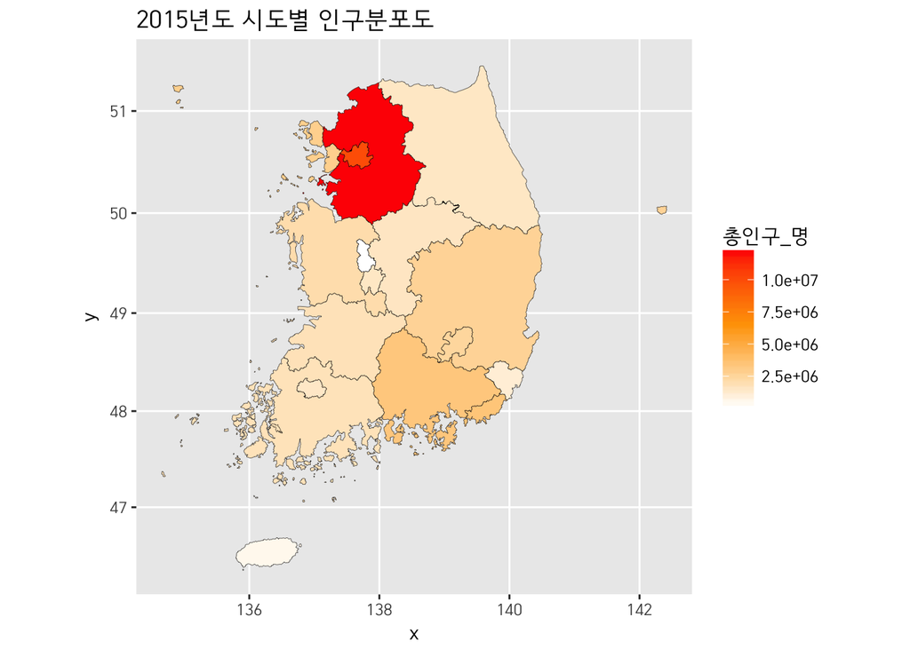

```r
library(ggplot2)
library(extrafont)
theme_set(theme_gray(base_family = "HCR Dotum LVT"))

ggplot(data = data_sido,
       aes(map_id = code,
           fill = 총인구_명)) +
        geom_map(map = kormap1,
                 colour = "black",
                 size = 0.1) +
        expand_limits(x = kormap1$long,
                      y = kormap1$lat) +
        scale_fill_gradientn(colours = c('white','orange','red')) +
        ggtitle("2015년도 시도별 인구분포도") +
        coord_map()
```

### ggChoropleth()함수를 이용한 단계구분도 그리기

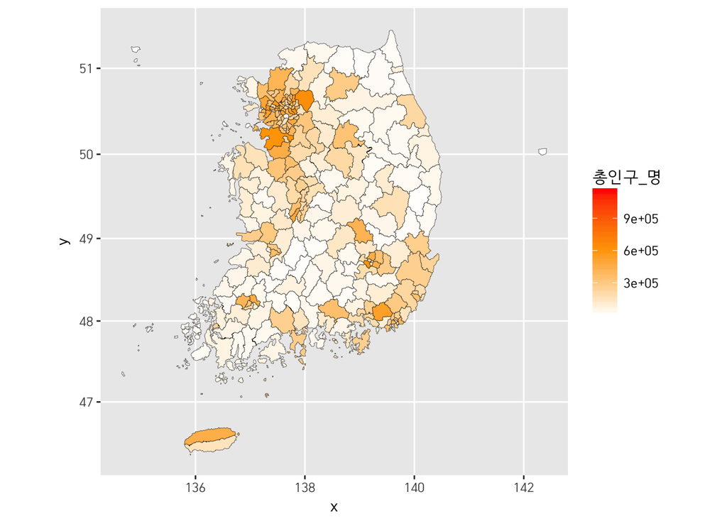

```r
library(ggiraph)
ggChoropleth(data_sgg, kormap2_2, fillvar = "총인구_명")
```

```r
# ggChoropleth(korpop2, kormap2,fillvar="총인구_명")
# ggChoropleth(korpop3,kormap3,fillvar="주택_계_호")
```

ggChoropleth()함수의 subarea인수를 이용하면 지도의 일부를 쉽게 그릴 수 있습니다. 예를 들어 호남지방의 단계구분도만 그리려면 다음과같이 할수 있습니다.

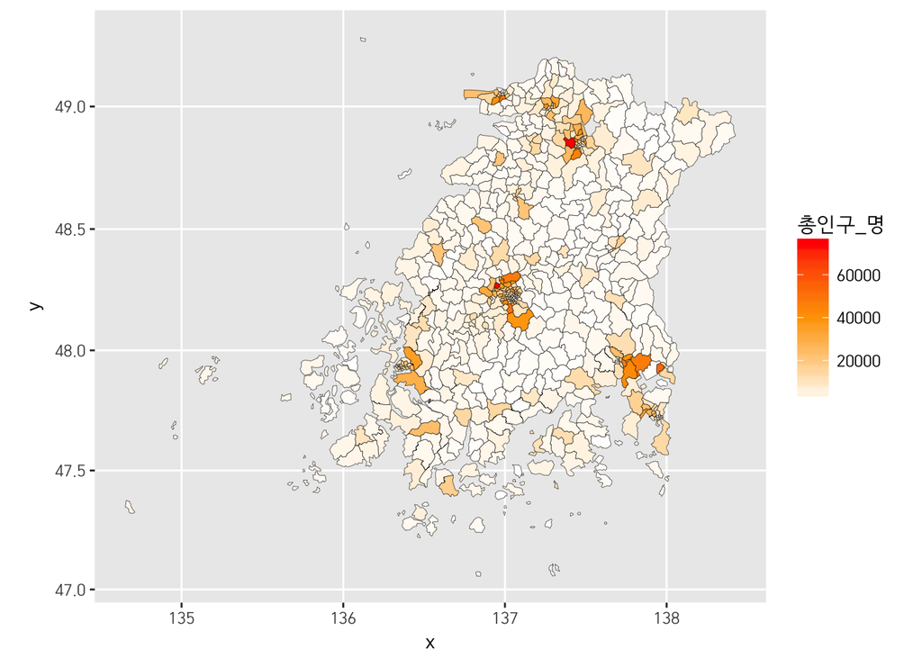

```r
ggChoropleth(korpop3,kormap3,fillvar="총인구_명",subarea=c("전라","광주"))
```

### ggChoropleth()함수를 이용한 Interactive Plot 그리기

```r
ggChoropleth(data_sgg,
             kormap2_2,
             fillvar = "총인구_명",
             interactive = TRUE,
             tooltip = "행정구역별_읍면동")
```

[interactive chart not shown]

### `subarea`

```r
ggChoropleth(data_emd,
             kormap3,
             fillvar = "총인구_명",
             interactive = TRUE,
             subarea = c("서울", "종로구"),
             tooltip = "행정구역별_읍면동")
```

[interactive chart not shown]